# Week 6

#Exercise 1

In this exercise, we continue the analysis of the white fish larval areas (week 2, exercise 3 and week4, exercise 2). This time we extend the model to include regression along two continues covariates in addition to the vegetation cover status. The additional covariates that we are interested in are the distance to sandy shore and the length of ice cover during winter. Many fishermen have observed that white fish are caught more easily from sandy shores than elsewhere during their spawning season. Moreover, white fish spawn their eggs during fall but the larvae hatch only in the spring. Hence, it has been suggested that longer ice cover period works as a shelter for the eggs. Hence, let’s take a look whether there is statistical signal to these covariates.

Let’s load the data and construct covariate matrix $X$ (a matrix where the $i$’th row contains the covariates for the $i$’th sampling site), vector of area indexes $a$ (areas in the code) and vector of white fish presence-absence observations $y$.

```r
# Read the data
data = read.csv("white_fishes_data.csv")

# Let's then take the covariates to matrix X and standardize them
X = data[,c("DIS_SAND","ICELAST09","BOTTOMCOV")]

# And for last let's take the presence-absence observations of white fish larvae into Y
y = data$WHIBIN
```

Unlike in our previous analyses of this data we treat each sampling site as one observation and consider the triplets $\{y_i,a_i,X_i\}$ ($X_i$ is the $i$’th row of $X$) exchangeable.

We will first build the following model to analyze the data.
$$\begin{align*}
y_{i} & \sim \text{Bernoulli}(\theta_{i})\\
\text{logit}(\theta_{i}) & = \alpha + X\beta \\
\alpha,\beta_1,\beta_2,\beta_3 &\sim N(0,10) \\
\end{align*}$$
Hence, we assume that the prior expectation of the probability to observe white fish larvae ($E[y_i]=\theta_i$) follows logit linear model where $\alpha$ is the intercept and $\beta$ is a $3\times 1$ vector of (fixed) effects of covariates. Note that the matrix notation $X\beta$ is the same as writing
$$X\beta =
\beta_1\times\text{DISSAND}+\beta_2\times\text{ICELAST09}+\beta_3\times
\text{BOTTOMCOV}$$

Note also that the DIS_SAND and ICELAST09 are continuous covariates whereas BOTTOMCOV is a categorical covariate getting value 1 if the bottom is covered by vegetation and 0 if the bottom is not covered by vegetation.

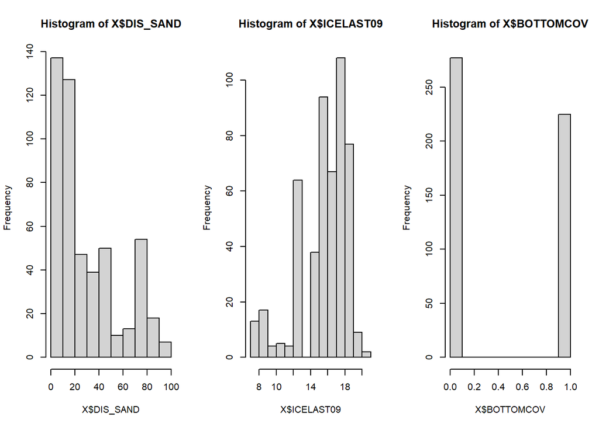

```r
par(mfrow=c(1,3))
hist(X$DIS_SAND)
hist(X$ICELAST09)
hist(X$BOTTOMCOV)
```

Hence, the parameter $\beta_3$ corresponds to the effect of vegetation to the observation probability of white fish larvae.

Before starting the analysis we standardize the continues covariates but not the categorical BOTTOMCOV covariate. If we standardized the categorical variable the interpretation of $\beta_3$ parameter would change.

```r
mx = colMeans(X[,1:2])
stdx = apply(X[,1:2],2,sd)
X[,1:2] = (X[,1:2]-t(replicate(dim(X)[1],mx)))/t(replicate(dim(X)[1],stdx))
```

**Task 1:**

Implement the model in Stan and sample from the posterior for the parameters $\alpha$ and $\beta$. Check for convergence of the MCMC chain and examine the autocorrelation of the samples. Visualize the posterior for $\alpha$ and $\beta$ and discuss the results.

First we define the model:

```r
logit_fish_model = "
data{
   int<lower = 0> n;
   real DIS_SAND[n];
   real ICELAST09[n];
   int BOTTOMCOV[n];
   int<lower=0,upper=1> y[n];
}

parameters{
   real alpha;
   real beta_1;
   real beta_2;
   real beta_3;
}

model{
   //priors:
   alpha ~ normal(0, sqrt(10));
   beta_1 ~ normal(0, sqrt(10));
   beta_2 ~ normal(0, sqrt(10));
   beta_3 ~ normal(0, sqrt(10));
   for (i in 1:n){
      y[i] ~ bernoulli_logit(alpha + beta_1*DIS_SAND[i] + beta_2*ICELAST09[i] + beta_3*BOTTOMCOV[i]);
   }
}

"
```

Then prepare the data:

```r
data <- list (n=length(y), DIS_SAND=X$DIS_SAND, ICELAST09=X$ICELAST09, BOTTOMCOV=X$BOTTOMCOV, y=y)
```

Then running the model:

```
##
## rstan version 2.26.13 (Stan version 2.26.1)
```

[output not shown]

```
## Do not specify '-march=native' in 'LOCAL_CPPFLAGS' or a Makevars file
```

```r
post=stan(model_code=logit_fish_model,data=data,warmup=500,iter=2000,chains=4,thin=1)
```

Convergence etc.:

```r
print(post)
```

```
## Inference for Stan model: anon_model.
## 4 chains, each with iter=2000; warmup=500; thin=1;
## post-warmup draws per chain=1500, total post-warmup draws=6000.
##
##           mean se_mean   sd    2.5%     25%     50%     75%   97.5% n_eff Rhat
## alpha     1.09    0.00 0.16    0.78    0.98    1.09    1.20    1.42  3710    1
## beta_1   -1.02    0.00 0.13   -1.28   -1.10   -1.01   -0.93   -0.76  4123    1
## beta_2    0.24    0.00 0.12    0.01    0.16    0.24    0.32    0.47  4114    1
## beta_3   -0.58    0.00 0.24   -1.04   -0.74   -0.58   -0.42   -0.12  3436    1
## lp__   -250.69    0.03 1.45 -254.41 -251.41 -250.33 -249.63 -248.91  2483    1
##
## Samples were drawn using NUTS(diag_e) at Mon Dec 12 18:53:28 2022.
## For each parameter, n_eff is a crude measure of effective sample size,
## and Rhat is the potential scale reduction factor on split chains (at
## convergence, Rhat=1).
```

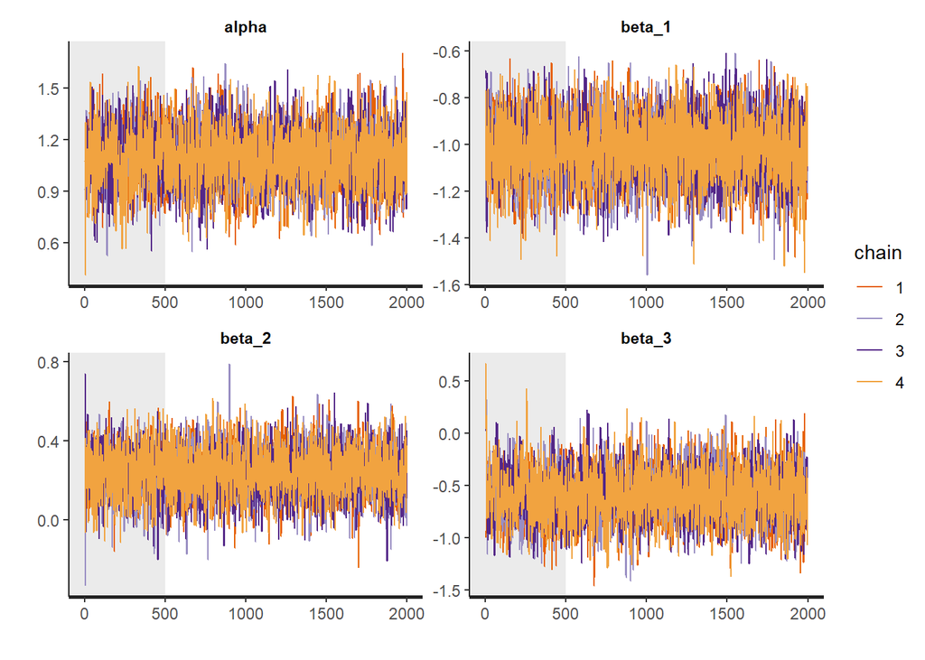

```r
plot(post,plotfun= "trace", inc_warmup = TRUE)
```

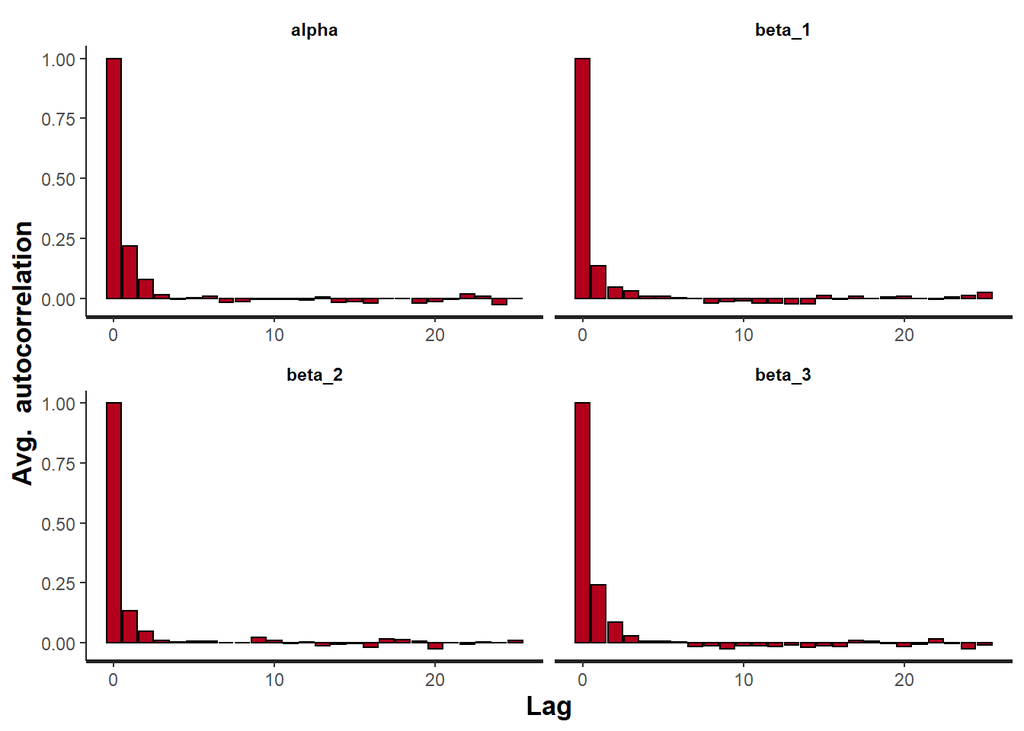

```r
stan_ac(post,inc_warmup = FALSE, lags = 25)
```

As we can conclude from above, the convergence and autocorrelation of the chains were in order. Rhats at 1, visually we can see that the chains have converged, and the autocorrelation is around zero at all higher lags.

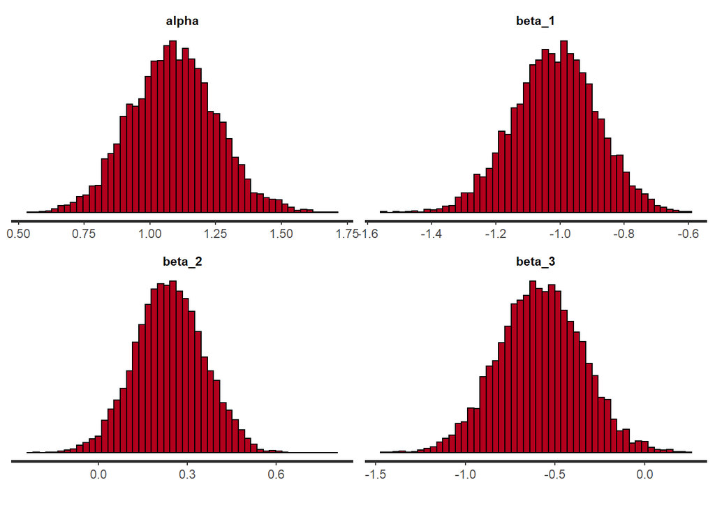

```r
Nsamp=as.matrix(post)
plot(post, plotfun = "hist", pars = list('alpha', 'beta_1', 'beta_2', 'beta_3') ,bins=50)
```

**Task 2.**

Calculate the posterior correlation between $\alpha$ and $\beta_3$. How does this differ from the prior correlation and why?

```r
corr <- cor(Nsamp[,'alpha'], Nsamp[,'beta_3'])
corr
```

```
## [1] -0.7249345
```

**Task 3.* Visualize the posterior of $\theta$ as a function of ICELAST09 when DISSAND is set to its mean value and in both cases when BOTTOMCOV=0 and BOTTOMCOV=1. That is, draw the median and 95% credible interval of the prediction function within the range from minimum to maximum value of ICELAST09 in the data.

```r
mean_sand = mean(X$DIS_SAND)
sigmoid = function(x) {
   1 / (1 + exp(-x))
}
```

```r
#beta_2s = Nsamp[, 'beta_2']*X$ICELAST09#calculate this individually for all values of icelast and plot median and confidence interval of result.
thetas_cov0 = array(dim=c(length(X$ICELAST09),3))
icelast <- X$ICELAST09
icelast <- sort(icelast)
```

```r
for (i in 1:502){
  bx <- Nsamp[, 'alpha'] + Nsamp[,'beta_1']*mean_sand +Nsamp[,'beta_2']*icelast[i] + Nsamp[,'beta_3'] * 0;
  theta <- sigmoid(bx)
  thetas_cov0[i,1] <- median(theta)
  thetas_cov0[i,2] <- quantile(theta,probs=c(0.025))
  thetas_cov0[i,3] <- quantile(theta,probs=c(0.975))
}
```

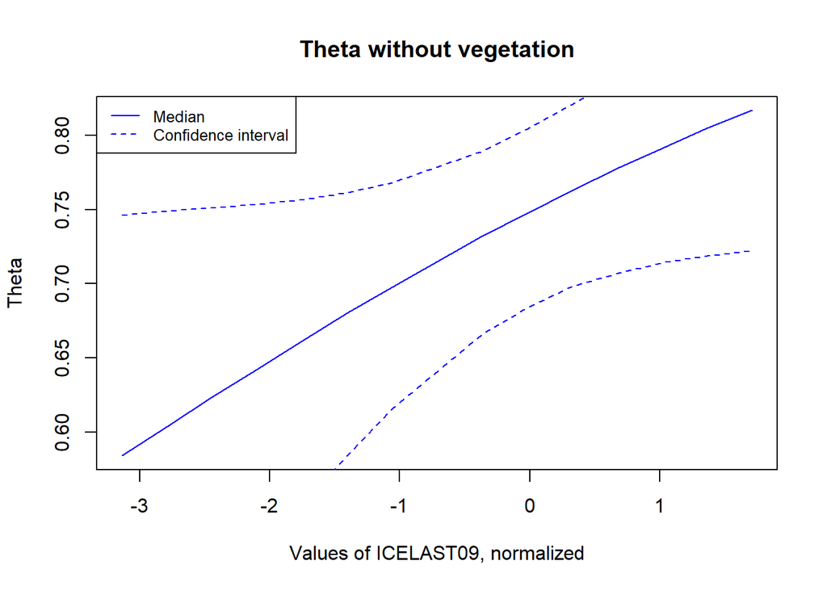

```r
plot(icelast,thetas_cov0[,1], col="blue", main="Theta without vegetation", type="l", xlab="Values of ICELAST09, normalized", ylab="Theta")
lines(icelast,thetas_cov0[,2], col="blue", lty=2, type='l')
lines(icelast,thetas_cov0[,3], col="blue", lty=2, type="l")
legend(x="topleft", legend=c("Median", "Confidence interval"),
       col=c("blue", "blue"), lty=1:2, cex=0.8)
```

```r
thetas_cov1 = array(dim=c(length(X$ICELAST09),3))
for (i in 1:502){
  bx2 <- Nsamp[, 'alpha'] + Nsamp[,'beta_1']*mean_sand +Nsamp[,'beta_2']*icelast[i] + Nsamp[,'beta_3'] * 1;
  #theta2 <- sigmoid(bx2)
  thetas_cov1[i,1] <- sigmoid(median(bx2))
  thetas_cov1[i,2] <- sigmoid(quantile(bx2,probs=c(0.025)))
  thetas_cov1[i,3] <- sigmoid(quantile(bx2,probs=c(0.975)))
}
```

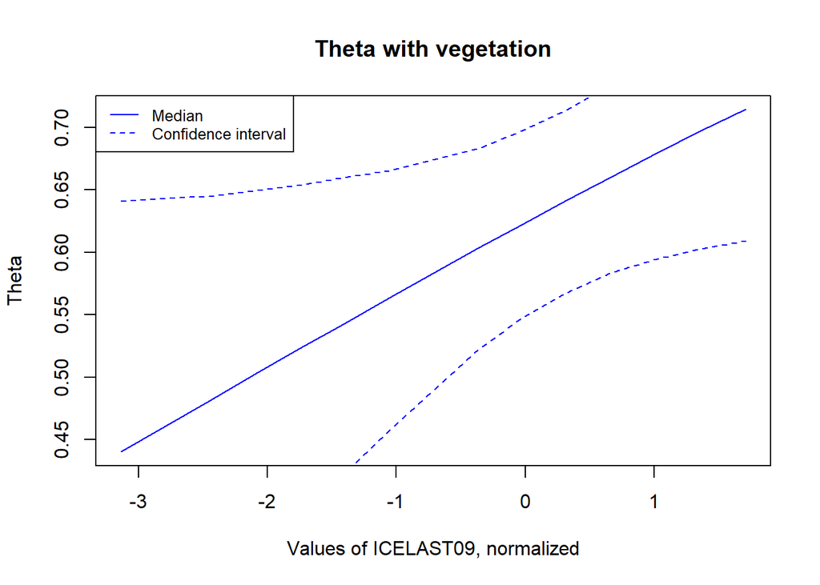

```r
plot(icelast,thetas_cov1[,1], col="blue", main="Theta with vegetation", type="l", xlab="Values of ICELAST09, normalized", ylab="Theta")
lines(icelast,thetas_cov1[,2], col="blue", lty=2, type='l')
lines(icelast,thetas_cov1[,3], col="blue", lty=2, type="l")
legend(x="topleft", legend=c("Median", "Confidence interval"),
       col=c("blue", "blue"), lty=1:2, cex=0.8)
```

**Task 4.**

Visualize the posterior distribution of $\theta$ at location where DIS_SAND is 60 and ICELAST is 18 for both vegetated and non-vegetated bottom types as well as their difference.

First normalizing the values given:

```r
sand <- (60-mx['DIS_SAND'])/stdx['DIS_SAND']
ice <- (18-mx['ICELAST09'])/stdx['ICELAST09']
print(sand)
```

```
## DIS_SAND
##  1.11729
```

```r
print(ice)
```

```
## ICELAST09
## 0.6707792
```

Then calculate thetas:

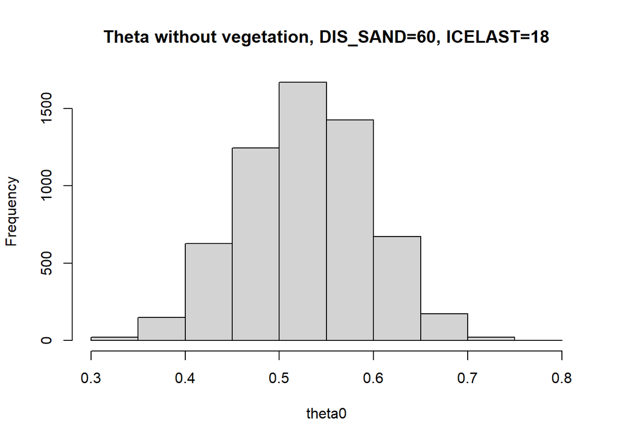

```r
bx0 <- Nsamp[, 'alpha'] + Nsamp[,'beta_1']*sand +Nsamp[,'beta_2']*ice + Nsamp[,'beta_3'] * 0;
theta0 <- sigmoid(bx0)

bx1 <- Nsamp[, 'alpha'] + Nsamp[,'beta_1']*sand +Nsamp[,'beta_2']*ice + Nsamp[,'beta_3'] * 1;
theta1 <- sigmoid(bx1)

hist(theta0, main="Theta without vegetation, DIS_SAND=60, ICELAST=18")
```

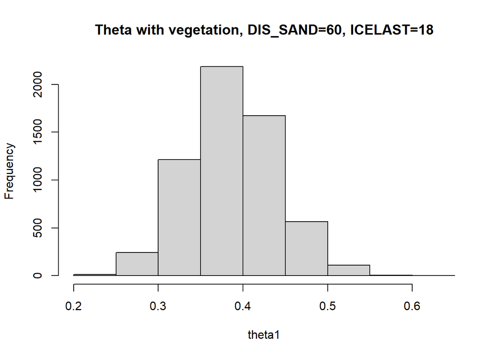

```r
hist(theta1, main="Theta with vegetation, DIS_SAND=60, ICELAST=18")
```

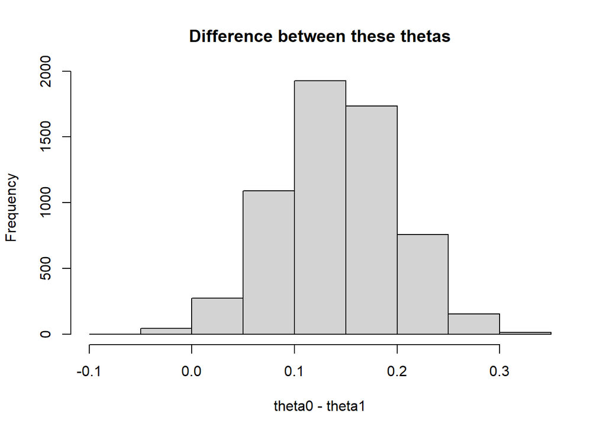

```r
hist(theta0-theta1, main="Difference between these thetas")
```

**Task 5.**

How does the difference in $\theta$ for vegetated and non-vegetated bottom differ from $\phi=\Delta \theta=\theta_0-\theta_1$ in exercise 3 of week 2 and $\delta \mu$ in exercise 2 of week 4? Would you say that the result concerning the effect of vegetation is consistent in all these different analyses? Which analysis would you prefer?

Compared to the difference of $\theta$ in week 2, the difference found here is somewhat smaller. The calculation in week 2 was a somewhat more naive approach, that did not take into considerations the difference between different areas. The difference found in week 4, again, is closer to this difference. As the calculation in week 4 took into consideration the possible differences in the sites, the logic of that $\theta$ is somewhat closer to this one, albeit the difference calculated above is for one specific site only.

The result is still somewhat consistent, a site without vegetation tends to have more white fish larvae than sites with vegetation.

In my own opinion, this last one seems the most compelling model, as here we are also trying to understand the factors that affect the occurence of white fish larvae in different sites, and therefore it is also more informative. By building this model, we can actually make some kind of inference for a new site without calculation, just by looking at those parameters that we have found to be important.

**Task 6.**

Visualize the posterior distribution of $\tilde{y}$ corresponding to the number sampling occasions where white fish is present out of a total 10 repeated sampling occasions at location where DIS_SAND is 60 and ICELAST is 18 for both vegetated and non-vegetated bottom types.

Drawing random samples:

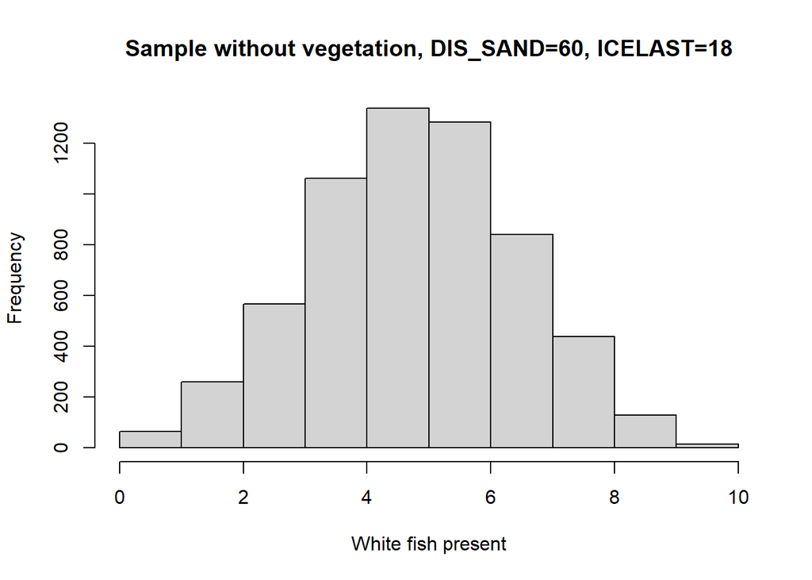

```r
sample_0 <- rbinom(theta0, 10, theta0)
sample_1 <- rbinom(theta1, 10, theta1)
hist(sample_0, main="Sample without vegetation, DIS_SAND=60, ICELAST=18", xlab="White fish present")
```

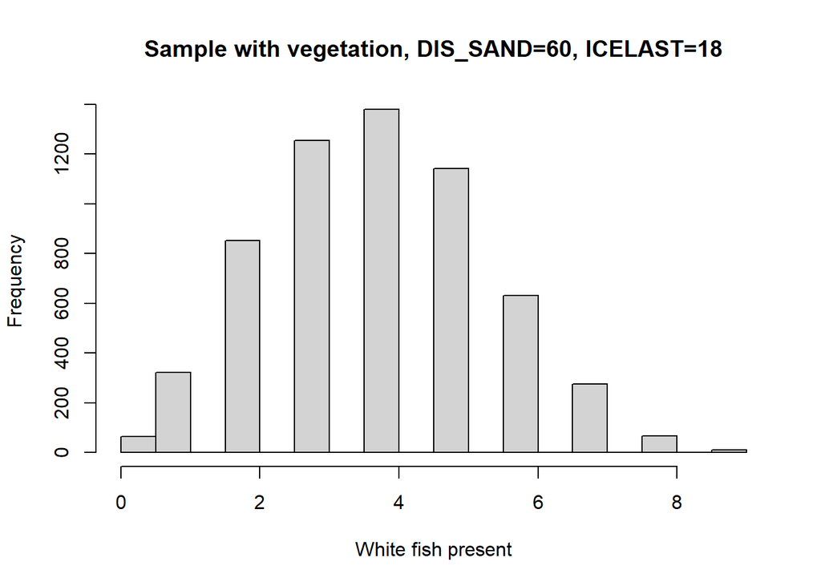

```r
hist(sample_1, main="Sample with vegetation, DIS_SAND=60, ICELAST=18", xlab="White fish present")
```

# Exercise 2

In the original Mauna Loa CO$_2$ data analysis we visualized the posterior predictive distribution of the expected CO$_2$ with respect to the month and compared it to the observed data points. This can be seen as one method for visual posterior predictive check. However, let’s continue model checking a bit more and then improve the model based on our findings.

To sample a replicate data set you must sample $\tilde{y} = [\tilde{y}_1,\dots,\tilde{y}_n]$ values from $\tilde{y}_i \sim N(\mu_i,\sigma^2)$, where $\mu_i = a + bx_i$ and $a, b, \sigma^2$ are drawn from the posterior. For example, pick 20 random triplets of $a, b, \sigma^2$ from the Markov chain and for each of them sample $\tilde{y}$. Then plot histogram of each $\tilde{y}$.\

Note! Since you are not asked about the parameter inference, you don’t need to worry about how to scale $\dot{c}$ back to $c$ even if you standardize your $y$ and $x$.

Conduct the posterior predictive comparison using the point-wise log predictive density
$$\text{lpd} =
\sum_{i=1}^{n_{\text{test}}} \log
p(\tilde{y}_i|\tilde{x}_i,y_{\text{training}},x_{\text{training}})$$
and the root mean squared error
$$\text{RMSE} = \sqrt{\frac{1}{n_{\text{test}}}
\sum_{i=1}^{n_{\text{test}}}(E[\tilde{y}_i|\tilde{x}_i,y_{\text{training}},x_{\text{training}}]-\tilde{y}_i)^2}$$
where $y_{\text{training}},x_{\text{training}}$ are the training and test data and $\tilde{y}_i,\tilde{x}_i$ are the test data points. Which of the models has better posterior predictive performance. Based on this results, does it seem that model M2 has overfitted the data?

Note,
$$\begin{align*}
p(\tilde{y}_i|\tilde{x}_i,y_{\text{training}},x_{\text{training}})&=\int
p(\tilde{y}_i|\tilde{x}_i,\theta)p(\theta|y_{\text{training}},x_{\text{training}})d\theta\\
& \approx \sum_{s=1}^Sp(\tilde{y}_i|\tilde{x}_i,\theta^{(s)})
\end{align*}$$
where $\theta^{(s)}$ is a sample from the posterior distribution of the parameters ($\theta=\{a,b,\sigma^2\}$ in the original model), that is $\theta^{(s)}\sim p(\theta|y_{\text{training}},x_{\text{training}})$.

Each of the above four tasks provides 5 points from correct implementation and answer. Each task gives 2 points if it is done towards right direction and partially correct.

Load the needed libraries.

```r
library(ggplot2)
library(StanHeaders)
library(rstan)
set.seed(123)

options(mc.cores = parallel::detectCores())
rstan_options(auto_write = TRUE)
```

Load the data and explore its properties

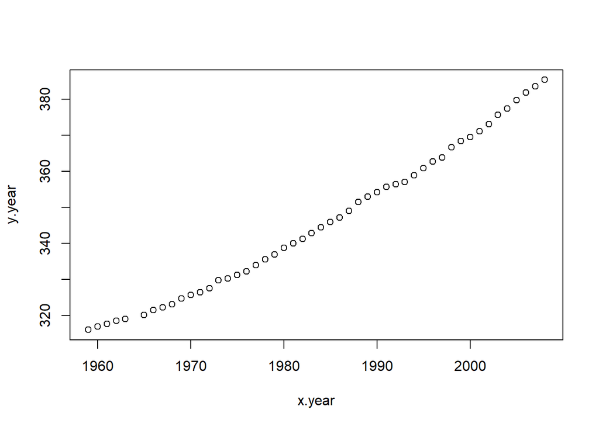

```r
# Load the data and explore it visually
maunaloa.dat = read.table("maunaloa_data.txt", header=FALSE, sep="\t")
# The columns are
# Year January February ... December Annual average

#  Notice! values -99.99 denote NA

# Let's take the yearly averages and plot them
x.year = as.vector(t(maunaloa.dat[,1]))
y.year = as.vector(t(maunaloa.dat[,14]))
# remove NA rows
x.year = x.year[y.year>0]
y.year = y.year[y.year>0]
plot(x.year,y.year)
```

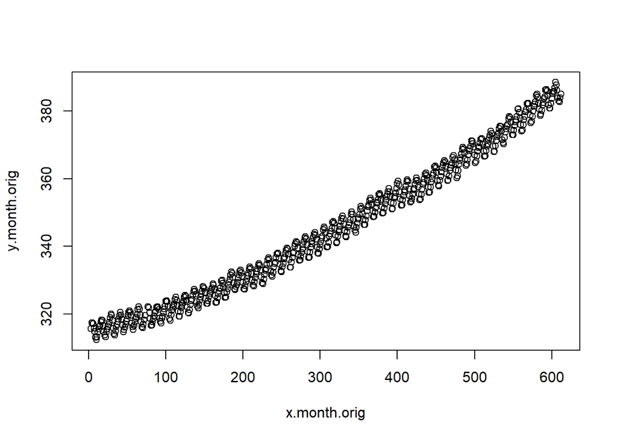

```r
# Let's take the monthy values and construct a "running month" vector
y.month.orig = as.vector(t(maunaloa.dat[,2:13]))
x.month.orig = as.vector(seq(1,length(y.month.orig),1))

# remove NA rows
x.month.orig = x.month.orig[y.month.orig>0]
y.month.orig = y.month.orig[y.month.orig>0]
plot(x.month.orig,y.month.orig)
```

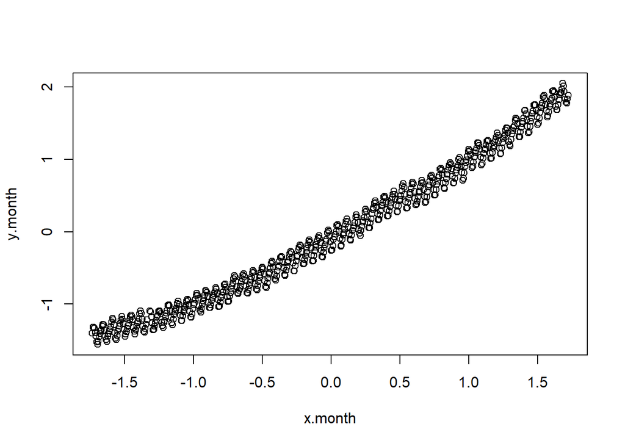

```r
# standardize y and x
my = mean(y.month.orig)
stdy = sd(y.month.orig)
y.month = (y.month.orig-my)/stdy

mx = mean(x.month.orig)
stdx = sd(x.month.orig)
x.month = (x.month.orig-mx)/stdx

plot(x.month,y.month)
```

```r
# data list
data <- list (N=length(x.month), y=y.month, x=x.month)
```

## Posterior predictive check

Analysis with the original model

$y_i = a + bx_i + \epsilon_i$

```r
mauna_loa_c02_model = "
data{
  int<lower=0> N; // number of observations
  real y[N];     // observed CO2 values
  real x[N];    // observed times
}
parameters{
  real a;
  real b;
  real<lower=0> sigma2;
}
transformed parameters{
  real<lower=0> sigma;
  real mu[N];

  sigma=sqrt(sigma2);

  for( i in 1 : N ) {
    mu[i] = a + b * x[i];
  }
}
model{
  a ~ normal( 0, sqrt(1e6));
  b ~ normal( 0, sqrt(1e6));
  sigma2 ~ inv_gamma(0.001,0.001);

  for( i in 1 : N ) {
    y[i] ~ normal(mu[i],sigma);
  }
}"
```

```r
set.seed(123)
post=stan(model_code=mauna_loa_c02_model,data=data,warmup=500,iter=2000,chains=4,thin=1,control = list(adapt_delta = 0.8,max_treedepth = 10))

# Check for convergence, see PSRF (Rhat in Stan)
print(post,pars=c("a","b","sigma2"))
```

```
## Inference for Stan model: anon_model.
## 4 chains, each with iter=2000; warmup=500; thin=1;
## post-warmup draws per chain=1500, total post-warmup draws=6000.
##
##        mean se_mean   sd  2.5%  25%  50%  75% 97.5% n_eff Rhat
## a      0.00       0 0.01 -0.01 0.00 0.00 0.00  0.01  6239    1
## b      0.99       0 0.01  0.98 0.98 0.99 0.99  1.00  7006    1
## sigma2 0.02       0 0.00  0.02 0.02 0.02 0.02  0.03  3775    1
##
## Samples were drawn using NUTS(diag_e) at Mon Dec 12 18:55:47 2022.
## For each parameter, n_eff is a crude measure of effective sample size,
## and Rhat is the potential scale reduction factor on split chains (at
## convergence, Rhat=1).
```

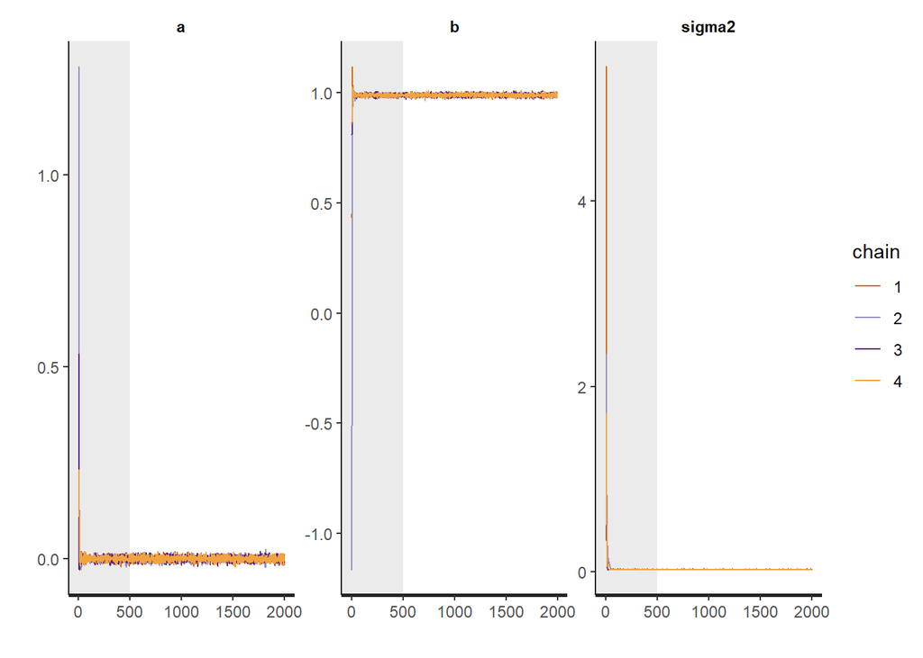

```r
#print(post)
plot(post, pars=c("a","b","sigma2"),plotfun= "trace", inc_warmup = TRUE)
```

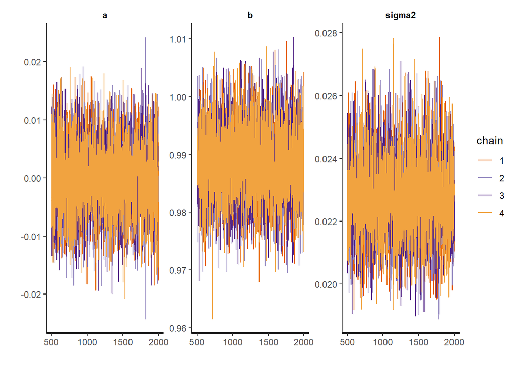

```r
plot(post, pars=c("a","b","sigma2"), plotfun= "trace", inc_warmup = FALSE)
```

The Rhat-values of 1 and the convergence seem good.

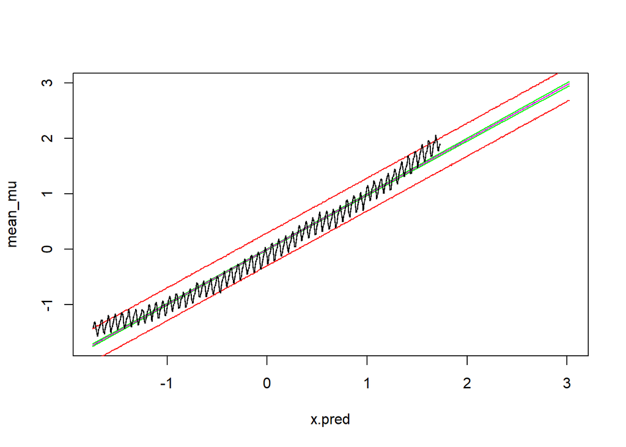

```r
set.seed(123)
# extract the samples into matrix
post_sample <- as.matrix(post, pars =c("a","b","sigma2"))    # combine all chains into one matrix in R workspace
a_dot=post_sample[,1]
b_dot=post_sample[,2]
sigma2_dot=post_sample[,3]


# This means that the prediction inputs have to be standardized as well

x.pred= (seq(1,70*12,length=70*12)-mx)/stdx
mu = matrix(NA,length(x.pred),length(b_dot))
y.tilde = matrix(NA,length(x.pred),length(b_dot))

mean_mu=rep(NA, length(x.pred))
int_mu = matrix(NA,length(x.pred),2)

mean_y=rep(NA, length(x.pred))
int_y = matrix(NA,length(x.pred),2)

for (i in 1:length(x.pred)) {
  #mu[i,] = (a + b*x.pred[i])*stdy + my
  mu[i,] = a_dot + b_dot*x.pred[i]
  mean_mu[i]=mean(mu[i,])
  int_mu[i,] = quantile(mu[i,],probs=c(0.025,0.975))
  #y_i = mu_i + e_i and e_i ~ N(0,sigma2)
  y.tilde[i,] =  mu[i,] + rnorm(length(mu[i,]), 0, sqrt(sigma2_dot))
  mean_y[i]=mean(y.tilde[i,])
  int_y[i,] = quantile(y.tilde[i,],probs=c(0.025,0.975))

}

plot(x.pred,mean_mu, type="l",col="blue") #posterior mean for mu(x)
lines(x.pred,int_mu[,1],col="green")
lines(x.pred,int_mu[,2],col="green") # 95% interval of mu(x)
lines(x.pred,mean_y, type="l",col="magenta") #posterior mean for y.tilde
lines(x.pred,int_y[,1],col="red")
lines(x.pred,int_y[,2],col="red") # 95% interval of y.tilde
lines(x.month,y.month)
points(x.month,y.month, cex=0.2)
```

Now we are ready to conduct the posterior predictive check

First, sample 20 random draws from the Markov chain

```r
set.seed(123)

pred_sample <- post_sample[sample(nrow(post_sample),size=20,replace=TRUE),]
```

```r
post_pred <- array(dim=c(20, length(x.month)))
for (i in 1:20){
  for (j in 1:length(x.month)){
    post_pred[i,j] <- rnorm(1, (pred_sample[i, 'a'] + pred_sample[i, 'b'] * x.month[j]), pred_sample[i, 'sigma2'])
  }
}
#for (i in 1:20){plot(x.month, post_pred[i,])}
```

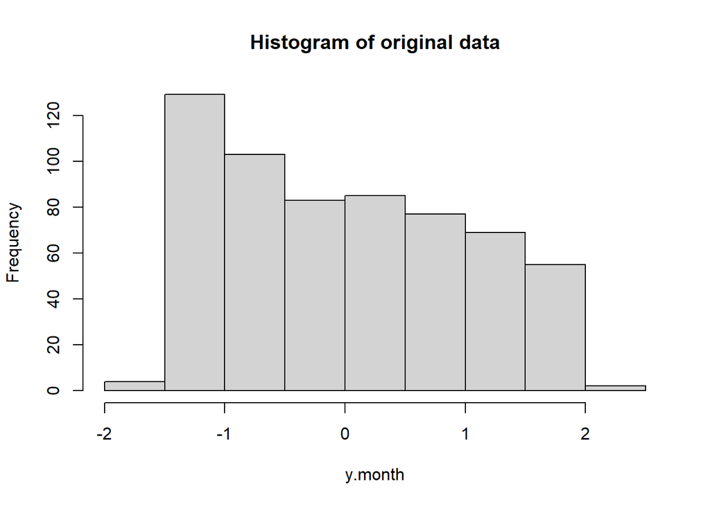

```r
hist(y.month, main = "Histogram of original data")
```

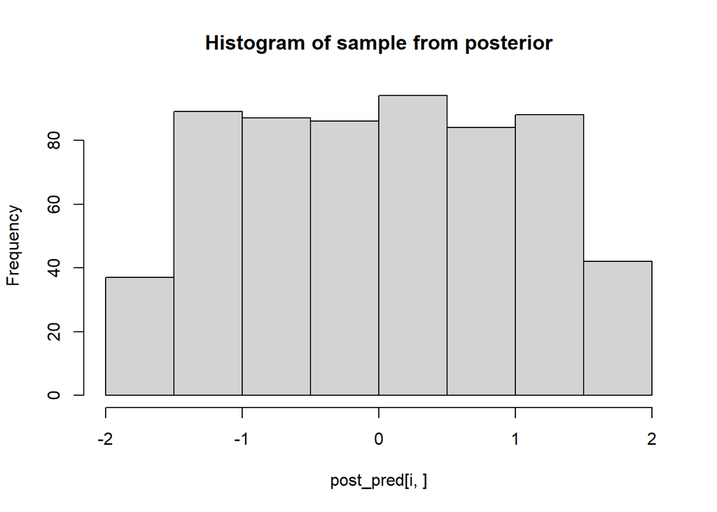

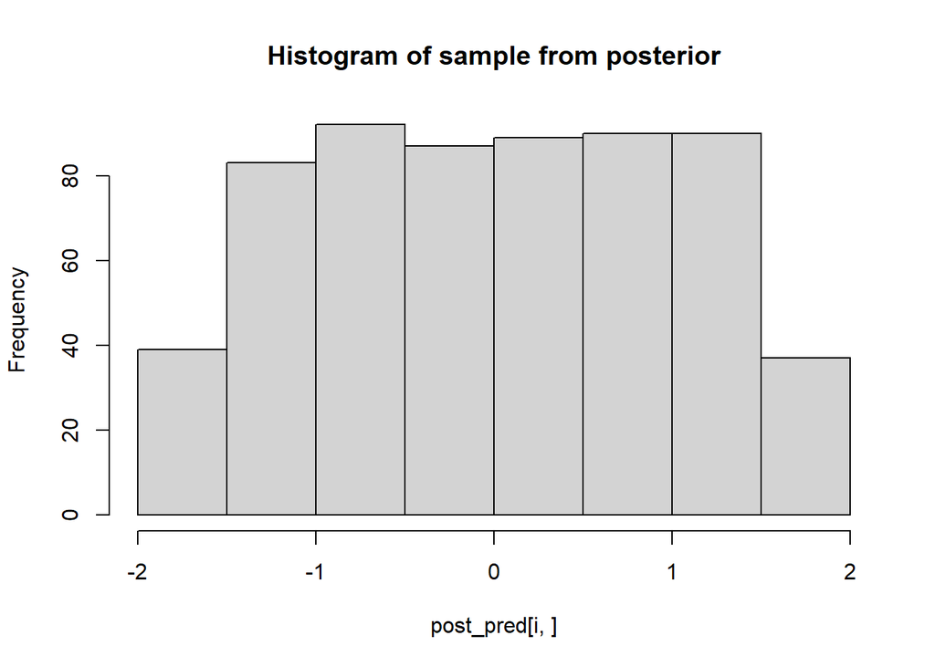

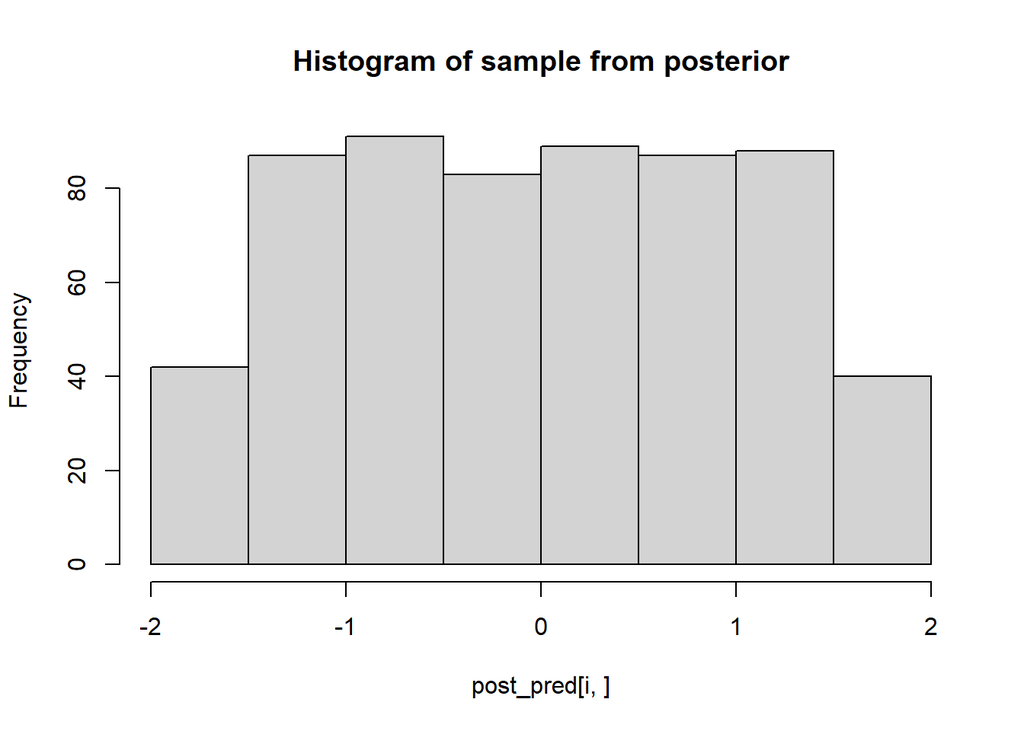

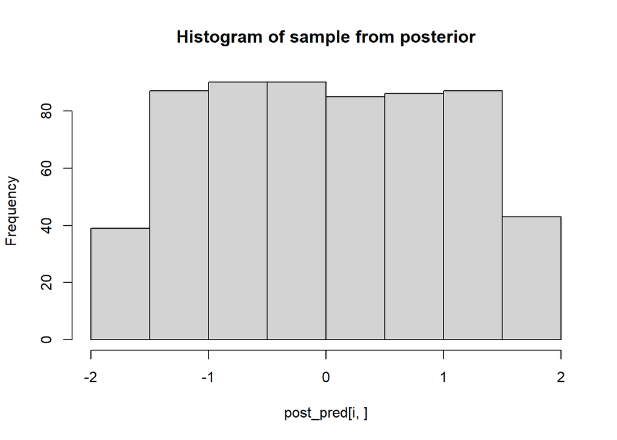

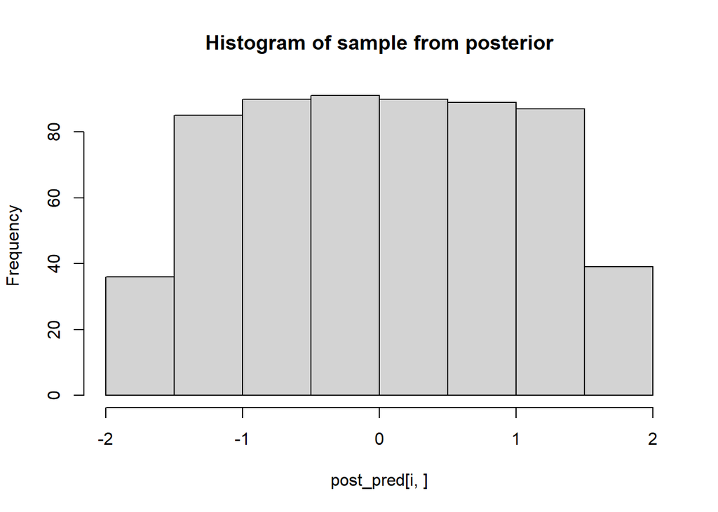

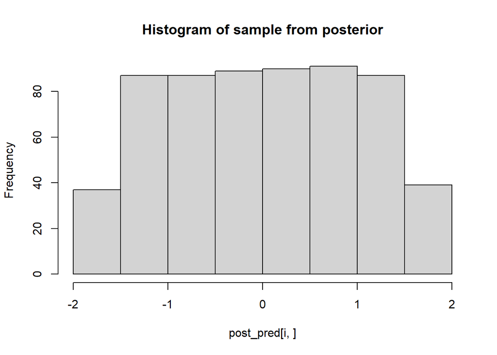

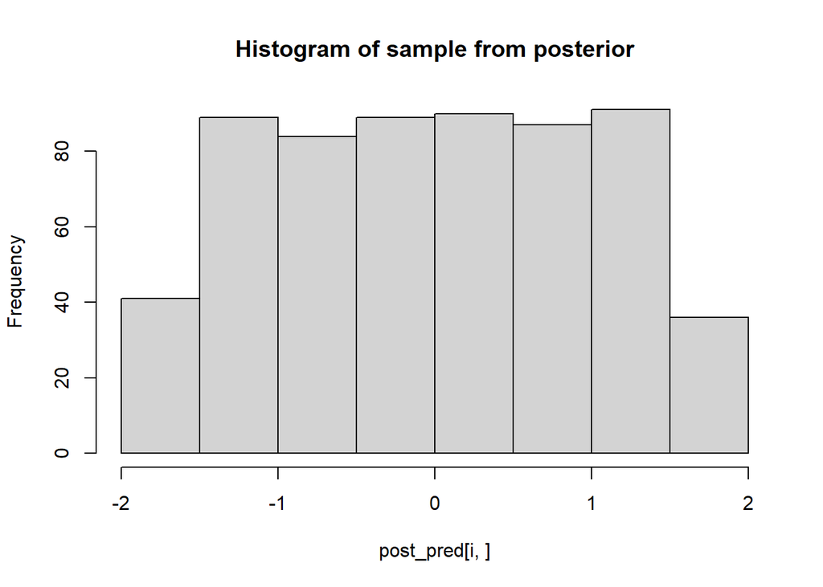

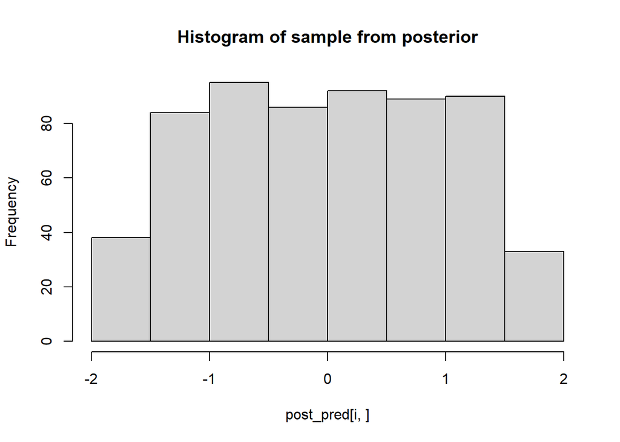

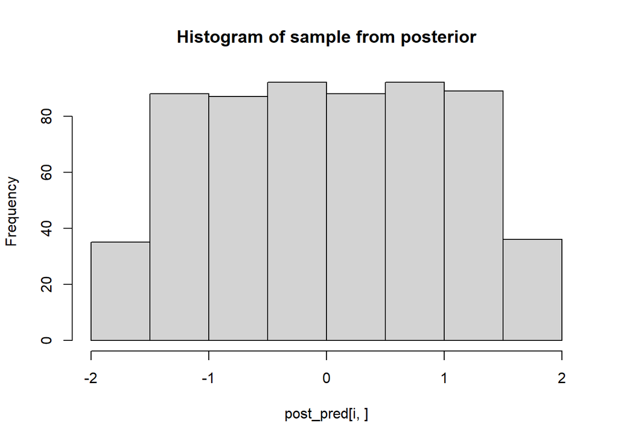

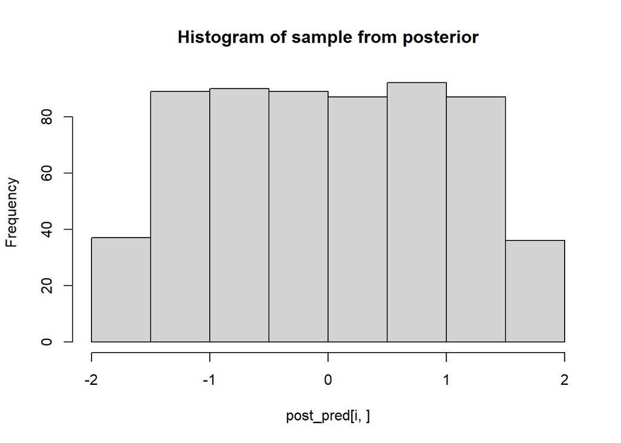

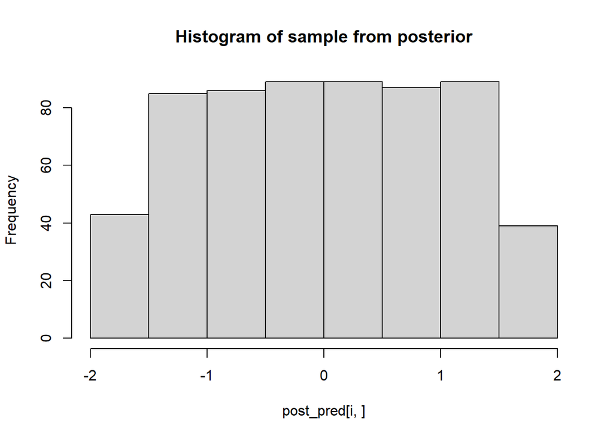

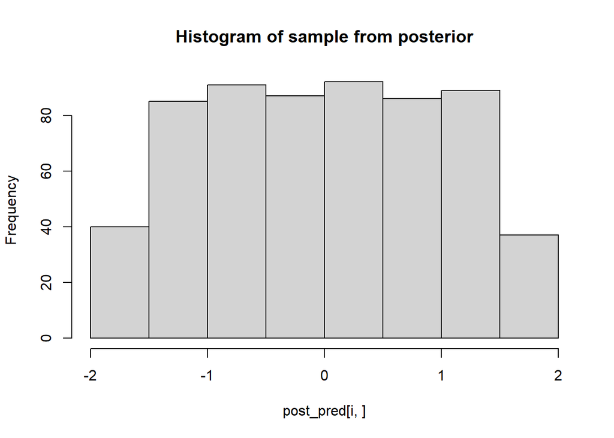

[8 more figures not shown]

```r
for (i in 1:20){hist(post_pred[i,], main="Histogram of sample from posterior")}
```

**Analysis:**

From the histograms we see that the posterior predictive samples are not very convincing. They are very evenly distributed over the range of x, while the original data was more heavy on the lower values. It seems like this model can not replicate this feature in the real data, and we probably ought to look for another, more correct model.

Let’s refine the model so that

$mu = a+b*x+c*x^2$

and rerun the analysis

```r
mauna_loa_c02_model2 = "
data{
  int<lower=0> N; // number of observations
  real y[N];     // observed CO2 values
  real x[N];    // observed times
}
parameters{
  real a;
  real b;
  real c;
  real<lower=0> sigma2;
}
transformed parameters{
  real<lower=0> sigma;
  real mu[N];

  sigma=sqrt(sigma2);

  for( i in 1 : N ) {
    mu[i] = a + b * x[i] + c * square(x[i]);
  }
}
model{
  a ~ normal( 0, sqrt(1e6));
  b ~ normal( 0, sqrt(1e6));
  c ~ normal( 0, sqrt(1e6));
  sigma2 ~ inv_gamma(0.001,0.001);

  for( i in 1 : N ) {
    y[i] ~ normal(mu[i],sigma);
  }
}
"
```

```r
post2=stan(model_code=mauna_loa_c02_model2,data=data,warmup=500,iter=2000,chains=4,thin=1,control = list(adapt_delta = 0.8,max_treedepth = 10))

# Check for convergence, see PSRF (Rhat in Stan)
print(post2,pars=c("a","b","c", "sigma2"))
```

```
## Inference for Stan model: anon_model.
## 4 chains, each with iter=2000; warmup=500; thin=1;
## post-warmup draws per chain=1500, total post-warmup draws=6000.
##
##         mean se_mean   sd  2.5%   25%   50%   75% 97.5% n_eff Rhat
## a      -0.12       0 0.01 -0.13 -0.13 -0.12 -0.12 -0.11  3724    1
## b       0.99       0 0.00  0.98  0.99  0.99  0.99  1.00  6807    1
## c       0.12       0 0.00  0.11  0.12  0.12  0.12  0.13  4280    1
## sigma2  0.01       0 0.00  0.01  0.01  0.01  0.01  0.01  3097    1
##
## Samples were drawn using NUTS(diag_e) at Mon Dec 12 18:58:14 2022.
## For each parameter, n_eff is a crude measure of effective sample size,
## and Rhat is the potential scale reduction factor on split chains (at
## convergence, Rhat=1).
```

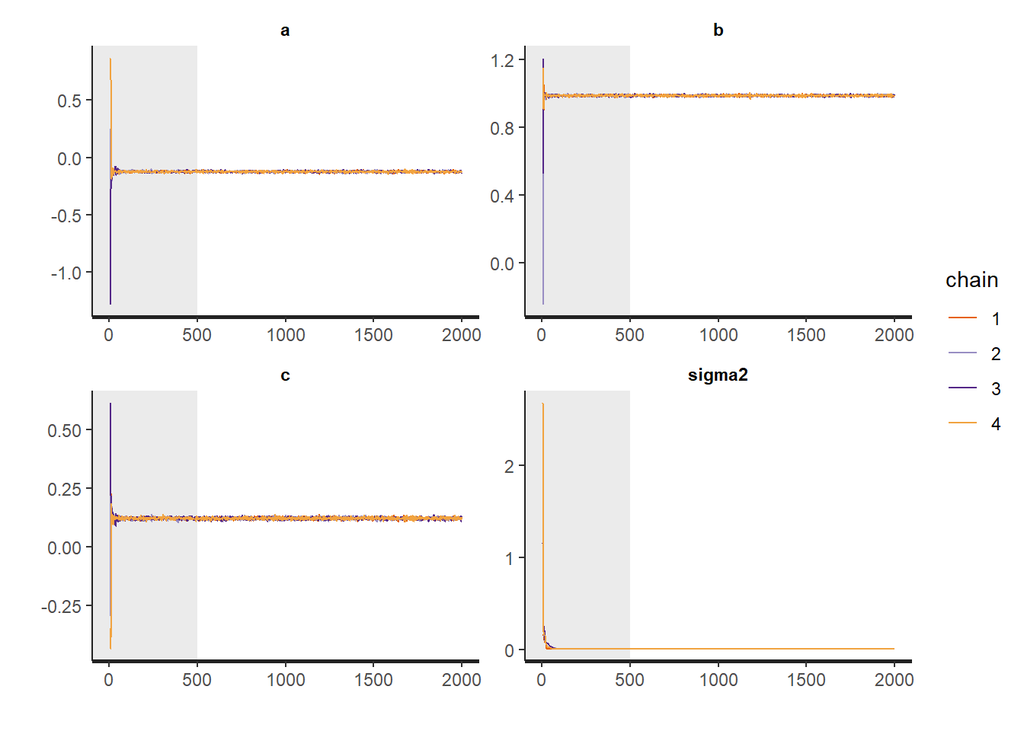

```r
#print(post)
plot(post2, pars=c("a","b", "c","sigma2"),plotfun= "trace", inc_warmup = TRUE)
```

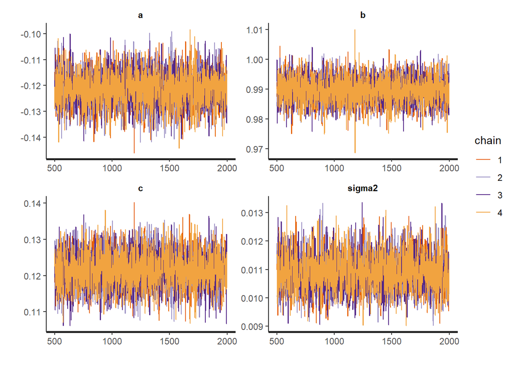

```r
plot(post2, pars=c("a","b", "c","sigma2"), plotfun= "trace", inc_warmup = FALSE)
```

The Rhat-values of 1 and the convergence and autocorrelation seem good.